# 第一步：导入Python库

```python
import os
import pandas as pd
import numpy as np
import statsmodels.api as sm
import matplotlib.pyplot as plt
import seaborn as sns
from sklearn.preprocessing import StandardScaler
```

```python
# 设置中文字体
plt.rcParams['font.sans-serif'] = ['SimHei', 'Arial Unicode MS', 'DejaVu Sans']
plt.rcParams['axes.unicode_minus'] = False
```

# 第二步：导入数据与整合数据

```python
#读取每个Excel文件的 '年度数据' 工作表
gdp = pd.read_excel('经济表现情况GDP与产业增长值.xls', sheet_name='年度数据', engine='xlrd')  # .xls 用 xlrd
employment = pd.read_excel('就业数据.xls', sheet_name='年度数据', engine='xlrd')
cpi = pd.read_excel('CPI与PPI数据.xls', sheet_name='年度数据', engine='xlrd')
population = pd.read_excel('人口统计数据.xls', sheet_name='年度数据', engine='xlrd')
HuiLv = pd.read_excel('汇率数据.xls', sheet_name='年度数据', engine='xlrd')
```

```python
# 从 GDP 开始
economic_data = gdp
# 依次合并其他数据（使用 outer join，保留所有年份）
economic_data = economic_data.merge(employment, on='时间', how='outer')
economic_data = economic_data.merge(cpi, on='时间', how='outer')
economic_data = economic_data.merge(population, on='时间', how='outer')
economic_data = economic_data.merge(HuiLv, on='时间', how='outer')
# 按年份排序
economic_data = economic_data.sort_values('时间').reset_index(drop=True)
```

```python
# 把数据复制到data
data=economic_data
```

```python
data['名义GDP增长率'] = data['国内生产总值(亿元)'].pct_change() * 100
data['CPI增长率'] = data['居民消费价格指数(上年=100)'] - 100
data['实际GDP增长率'] = data['名义GDP增长率'] - data['CPI增长率']
data['就业增长率'] = data['就业人员(万人)'].pct_change() * 100
data['就业弹性系数'] = data['就业增长率'] / data['名义GDP增长率']
data['人口增长率'] = data['年末总人口(万人)'].pct_change() * 100
data['人均GDP增长率'] = data['名义GDP增长率'] - data['人口增长率']
data['劳动年龄人口_估算'] = data['年末总人口(万人)'] * 0.4
data['劳动参与率'] = data['就业人员(万人)'] / data['劳动年龄人口_估算']
data['失业率_估算'] = (data['劳动年龄人口_估算'] - data['就业人员(万人)']) / data['劳动年龄人口_估算']
data['通胀调整失业率'] = data['失业率_估算'] * (1 + data['CPI增长率']/100)
# 计算汇率增长率（负值表示人民币贬值）
data['汇率增长率_美元'] = data['人民币对美元汇率(美元=100)(元)'].pct_change() * 100
```

## 第一个课题 通胀成本与经济增长表现情况

### CPI通货膨胀与经济增长表现数据关系探索

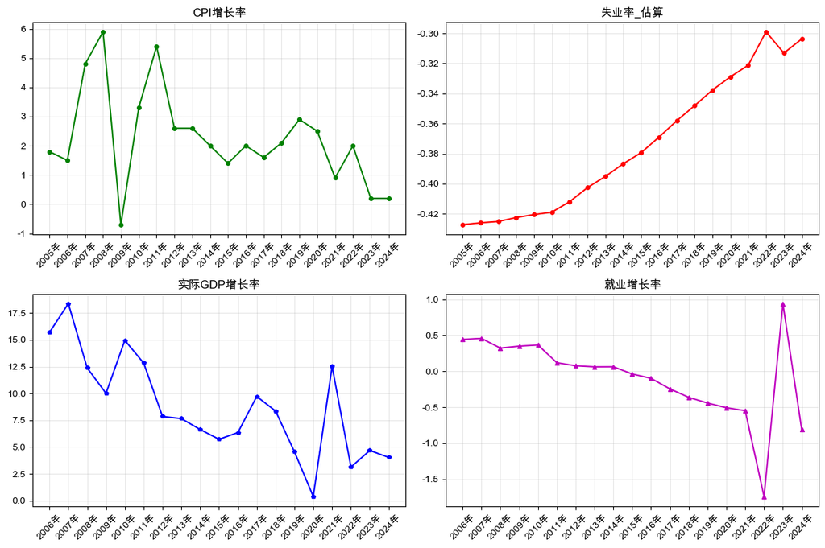

```python
# 设置图形大小
plt.figure(figsize=(12, 8))
# 1. CPI增长率
plt.subplot(2, 2, 1)
plt.plot(data['时间'], data['CPI增长率'], 'g-o', linewidth=1.5, markersize=4)
plt.title('CPI增长率')
plt.grid(True, alpha=0.3)
plt.xticks(rotation=45)

# 2. 失业率_估算
plt.subplot(2, 2, 2)
plt.plot(data['时间'], data['失业率_估算'], 'o-r', linewidth=1.5, markersize=4)
plt.title('失业率_估算')
plt.grid(True, alpha=0.3)
plt.xticks(rotation=45)

# 3. 实际GDP增长率
plt.subplot(2, 2, 3)
plt.plot(data['时间'], data['实际GDP增长率'], 'p-b', linewidth=1.5, markersize=4)
plt.title('实际GDP增长率')
plt.grid(True, alpha=0.3)
plt.xticks(rotation=45)

# 4. 通胀调整失业率
plt.subplot(2, 2, 4)
plt.plot(data['时间'], data['就业增长率'], '^-m', linewidth=1.5, markersize=4)
plt.title('就业增长率')
plt.grid(True, alpha=0.3)
plt.xticks(rotation=45)

# 自动调整布局
plt.tight_layout()
# 显示图形
plt.show()
```

## 建模探索

```python
X= data[['CPI增长率', '人口增长率', '劳动参与率']].dropna()
y = data['实际GDP增长率'].dropna()
model1 = sm.OLS(y, X).fit()
print("模型1：实际GDP增长率 ~ CPI增长率 + 人口增长率 + 劳动参与率")
print(model1.summary())
```

```
模型1：实际GDP增长率 ~ CPI增长率 + 人口增长率 + 劳动参与率
                                 OLS Regression Results
=======================================================================================
Dep. Variable:               实际GDP增长率   R-squared (uncentered):                   0.841
Model:                            OLS   Adj. R-squared (uncentered):              0.811
Method:                 Least Squares   F-statistic:                              28.25
Date:                Wed, 06 Aug 2025   Prob (F-statistic):                    1.25e-06
Time:                        16:45:51   Log-Likelihood:                         -52.997
No. Observations:                  19   AIC:                                      112.0
Df Residuals:                      16   BIC:                                      114.8
Df Model:                           3
Covariance Type:            nonrobust
==============================================================================
                 coef    std err          t      P>|t|      [0.025      0.975]
------------------------------------------------------------------------------
CPI增长率         0.7359      0.657      1.120      0.279      -0.656       2.128
人口增长率          4.6875      4.100      1.143      0.270      -4.004      13.379
劳动参与率          3.8425      1.455      2.641      0.018       0.759       6.926
==============================================================================
Omnibus:                        0.948   Durbin-Watson:                   1.460
Prob(Omnibus):                  0.623   Jarque-Bera (JB):                0.904
Skew:                           0.405   Prob(JB):                        0.636
Kurtosis:                       2.303   Cond. No.                         13.1
==============================================================================

Notes:
[1] R² is computed without centering (uncentered) since the model does not contain a constant.
[2] Standard Errors assume that the covariance matrix of the errors is correctly specified.
```

## 第三课题 汇率对于经济发展情况研究

核心逻辑，理论框架：人民币贬值 → 出口竞争力↑ → 净出口↑ → 总需求↑ → GDP增长↑ → 经济发展质量提升

### 建立模型

```python
import statsmodels.api as sm

X = data[['汇率增长率_美元']].dropna()
X = sm.add_constant(X)
y = data['实际GDP增长率'].dropna()

# 对齐索引
X, y = X.align(y, join='inner', axis=0)

model = sm.OLS(y, X).fit()
print(model.summary())
```

```
                            OLS Regression Results
==============================================================================
Dep. Variable:               实际GDP增长率   R-squared:                       0.434
Model:                            OLS   Adj. R-squared:                  0.401
Method:                 Least Squares   F-statistic:                     13.04
Date:                Wed, 06 Aug 2025   Prob (F-statistic):            0.00216
Time:                        16:45:53   Log-Likelihood:                -50.637
No. Observations:                  19   AIC:                             105.3
Df Residuals:                      17   BIC:                             107.2
Df Model:                           1
Covariance Type:            nonrobust
==============================================================================
                 coef    std err          t      P>|t|      [0.025      0.975]
------------------------------------------------------------------------------
const          8.2129      0.855      9.601      0.000       6.408      10.018
汇率增长率_美元      -0.7877      0.218     -3.611      0.002      -1.248      -0.327
==============================================================================
Omnibus:                        0.470   Durbin-Watson:                   1.430
Prob(Omnibus):                  0.790   Jarque-Bera (JB):                0.096
Skew:                           0.173   Prob(JB):                        0.953
Kurtosis:                       2.958   Cond. No.                         3.99
==============================================================================

Notes:
[1] Standard Errors assume that the covariance matrix of the errors is correctly specified.
```

### 汇率变化金融传导到实体具有滞后性！动态模型探索

```python
# 构建滞后变量
data['汇率变化_美元_滞后1'] = data['汇率增长率_美元'].shift(1)
data['汇率变化_美元_滞后2'] = data['汇率增长率_美元'].shift(2)

# 回归含滞后项

X = sm.add_constant(data[['汇率增长率_美元', '汇率变化_美元_滞后1', '汇率变化_美元_滞后2']].dropna())
y = data['实际GDP增长率'].reindex(X.index)

model_lag = sm.OLS(y, X).fit()

print(model_lag.summary())
```

```
                            OLS Regression Results
==============================================================================
Dep. Variable:               实际GDP增长率   R-squared:                       0.468
Model:                            OLS   Adj. R-squared:                  0.345
Method:                 Least Squares   F-statistic:                     3.809
Date:                Wed, 06 Aug 2025   Prob (F-statistic):             0.0369
Time:                        16:49:54   Log-Likelihood:                -41.538
No. Observations:                  17   AIC:                             91.08
Df Residuals:                      13   BIC:                             94.41
Df Model:                           3
Covariance Type:            nonrobust
===============================================================================
                  coef    std err          t      P>|t|      [0.025      0.975]
-------------------------------------------------------------------------------
const           7.3243      0.807      9.076      0.000       5.581       9.068
汇率增长率_美元       -0.6404      0.208     -3.082      0.009      -1.089      -0.191
汇率变化_美元_滞后1    -0.0049      0.211     -0.023      0.982      -0.461       0.451
汇率变化_美元_滞后2    -0.2131      0.214     -0.997      0.337      -0.675       0.249
==============================================================================
Omnibus:                        3.319   Durbin-Watson:                   1.738
Prob(Omnibus):                  0.190   Jarque-Bera (JB):                1.284
Skew:                          -0.480   Prob(JB):                        0.526
Kurtosis:                       3.944   Cond. No.                         5.04
==============================================================================

Notes:
[1] Standard Errors assume that the covariance matrix of the errors is correctly specified.
```

政策建议

汇率政策：适度保持人民币汇率稳定，避免大幅贬值或升值。

产业结构优化：继续推动工业化进程，提升工业占比，增强经济增长潜力。

进一步研究：补充进出口数据，构建更全面的模型，验证汇率变动对经济增长的具体机制。